# Repdata-PA N1

Alessio Ballesio

27/6/2020

Setting up analysis by set the working directory and read the data

```r
setwd("C:/Users/aless/Documents/data science/course n5 - reproducible research/Repdata-peerassessment1")
activity <- read.csv("activity.csv", header= TRUE)
```

First question asks to calculate the mean of steps. To do this I first need to calculate the number of steps done each day. Then I first plot histogram of the results using the base plot systems As second step, calculate the mean and median values

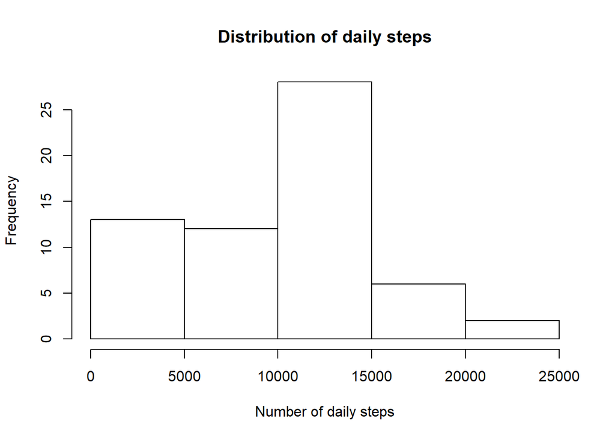

```r
total_daily_steps<- tapply(activity$steps,activity$date,sum,na.rm = TRUE)
histogram <- hist(total_daily_steps, xlab= "Number of daily steps", main = "Distribution of daily steps")
```

```r
dev.copy(png, file = "Distribution of daily steps.png")
```

```r
dev.off()
```

```r
mean_daily_steps <- mean(total_daily_steps)
mean_daily_steps
```

```
## [1] 9354.23
```

```r
median_daily_steps <- median(total_daily_steps)
median_daily_steps
```

```
## [1] 10395
```

## SECONd QUESTION - What is the average daily activity pattern?

First of all I need to calculate, using again tapply function the average steps for each interval across all days. In order to make a time series plot of the 5-minute interval (x-axis) and the average number of steps taken averaged across all days (y-axis). I then plot the function.

```r
library(dplyr)
```

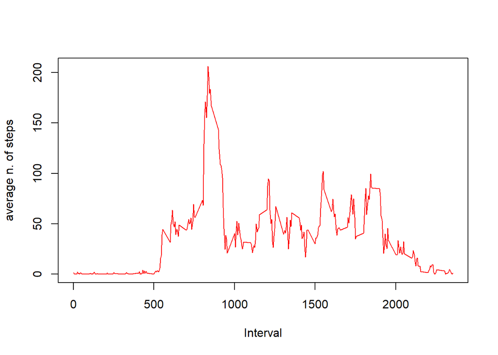

```r
intervals <- group_by(activity, interval)
average_steps_interval <- summarise(intervals,steps=mean(steps,na.rm=TRUE))
# putting into a new png file
plot(average_steps_interval, type= "l", col = "red", xlab = "Interval", ylab= "average n. of steps")
```

```r
dev.copy(png, file = "average daily activity.png")
```

```r
dev.off()
```

The second part of question asks to determine which is interval with the highest average number of steps. For this, I use the which.max function

```r
max_interval <- average_steps_interval[which.max(average_steps_interval$steps),]
max_interval
```

```
## # A tibble: 1 x 2
##   interval steps
##      <int> <dbl>
## 1      835  206.
```

THIRD STEP - Imputing missing values

First of all I calculate the total number of rows (intervals) for which there is no value. I use function sum(is.na())

```r
Number_missing_values <- sum(is.na(activity$steps))
Number_missing_values
```

```
## [1] 2304
```

```r
missing_values <- is.na(activity$steps)
value_to_add <- mean(activity$steps,na.rm=TRUE)
activity_processed <- activity
activity_processed[missing_values,3] <- value_to_add
```

I then create the histogram of this new dataset

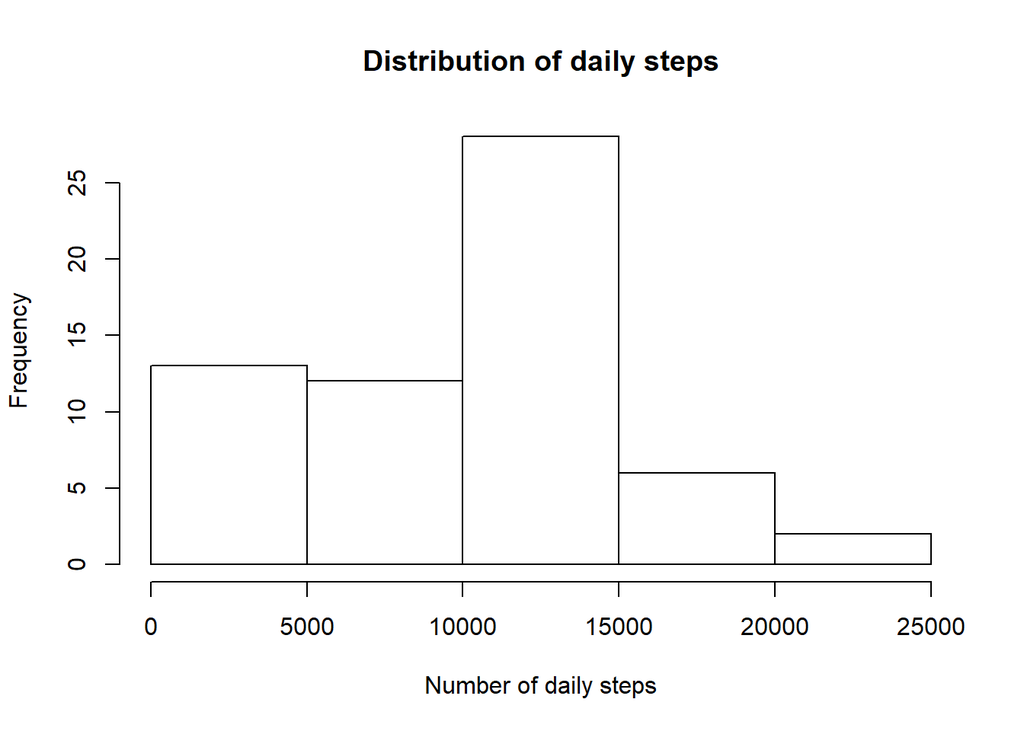

```r
total_daily_steps_processed<- tapply(activity_processed$steps,activity$date,sum,na.rm = TRUE)
histogram <- hist(total_daily_steps_processed, xlab= "Number of daily steps", main = "Distribution of daily steps")
```

```r
dev.copy(png, file = "Distribution of daily steps-with NA replaced.png")
```

```r
dev.off()
```

and calcuate the mean and median

```r
mean_daily_steps_processed <- mean(total_daily_steps_processed)
mean_daily_steps_processed
```

```
## [1] 9354.23
```

```r
median_daily_steps_processed <- median(total_daily_steps_processed)
median_daily_steps_processed
```

```
## [1] 10395
```

PART 4 - Are there differences in activity patterns between weekdays and weekends?

First step is to create a new factor variable in the dataset with two levels – “weekday” and “weekend” indicating whether a given date is a weekday or weekend day.

```r
activity_processed$day <- weekdays(as.Date(activity_processed$date))
activity_processed$day_type <- ifelse(activity_processed$day=='sabato' | activity_processed$day=='domenica', 'weekend','weekday')
```

Then I pass to create a time series plot (i.e. type = “l”) of the 5-minute interval (x-axis) and the average number of steps taken, averaged across all weekday days or weekend days (y-axis). See the README file in the GitHub repository to see an example of what this plot should look like using simulated data.

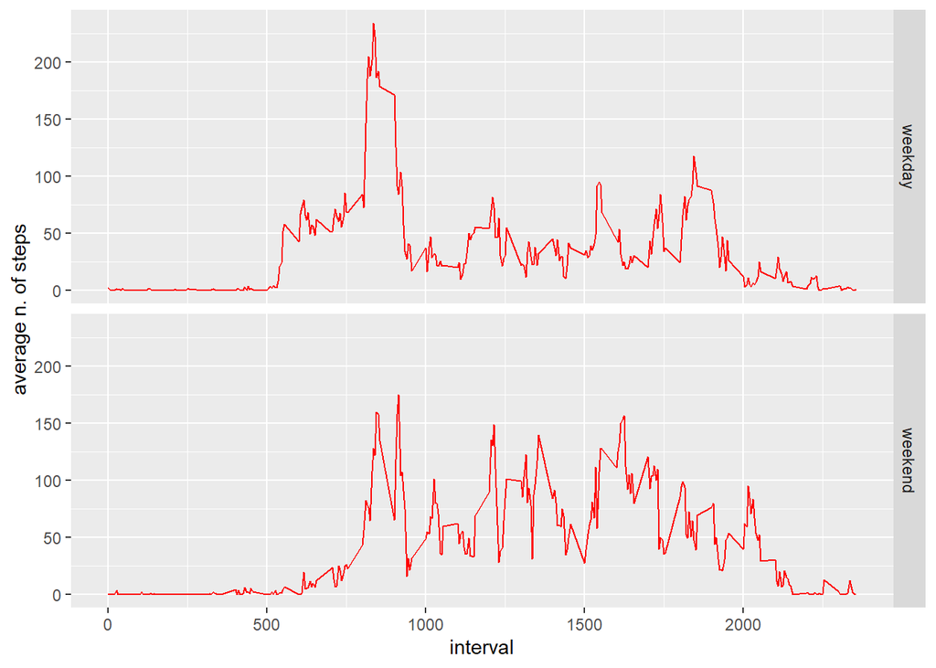

```r
average_steps_interval_and_daytype <- aggregate(steps~interval+day_type,data=activity_processed,FUN=mean,na.action=na.omit)
library(ggplot2)
plot <- ggplot(average_steps_interval_and_daytype,aes(interval,steps))
plot+geom_line(col="red") + facet_grid(day_type ~ .)+ xlab("interval")+ylab("average n. of steps")
```

```r
dev.copy(png, file= "weekdays vs weekend.png")
```

```r
dev.off()
```

END